# User Trends of the Ford GoBike

## by Ryan Sikhrangkur

## Investigation Overview

In this investigation, I want to look at how the Ford GoBike usage trends based on user type and how those trips are used by day of the week. The main focus was on user type, duration traveled (in seconds), distance traveled (in meters), and dates and times of the trips.

## Dataset Overview

The dataset contains a record of over 180,000 uses of Ford GoBikes in the San Fransisco Bay area for February 2019, and includes information providing details of bike trips such station names, IDs, longitude and latitude locations. It also includes user information such as user type, gender and year of birth. 3,880 entries have been removed from this dataset for having recorded a travel distance of 0 meters which would cause inaccurate readings.

## Percentage of Trips

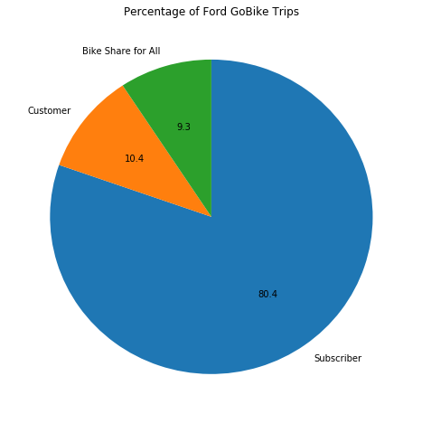

## Distribution of Travel Time

Trip times recorded in the dataset have a very large range of values, with the minimum value being 61 seconds and the maximum being shy an *entire day* at 85,444 seconds. By viewing this data under a logarithmic scale, the distribution of trip time is unimodal in shape.

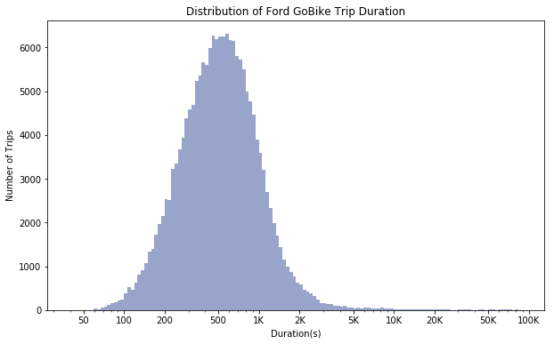

## Distribution of Travel Distance

Much like trip duration, the dataset has an equally large range of values with a minimum value of 13 meters and a maximum value of 69,469 meters. Viewing the data with an upper limit of 6000 meters captures 99.6% of the data, and shows a unimodal shape skewed to the right.

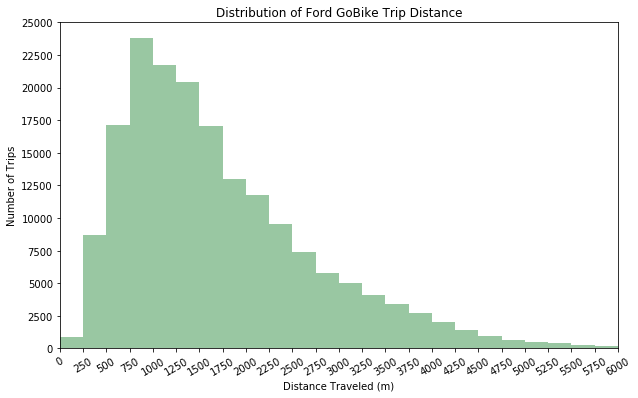

## Trips by Day

By manipulating the time variables within the dataset, trips can be viewed by day. The plot reveals significantly less trips made for Saturday and Sunday, with more than 10,000 less trips than the lowest weekday.

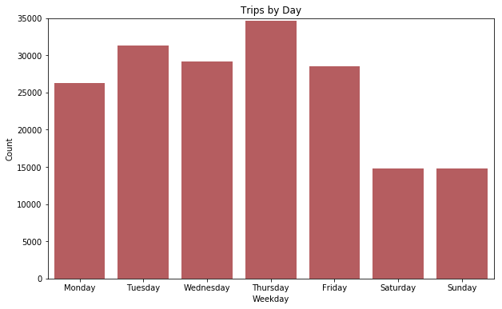

## Travel Time vs. Distance

By plotting the trip time on a logarithmic scale and limiting the trip distance as before reveals a fairly exponential relationship where a majority of the data is concentrated within the ranges of 60-2,000 seconds and 150-6,000 meters. For trip time beyond approximately 1,800 seconds, there is no real relationship with trip distance.

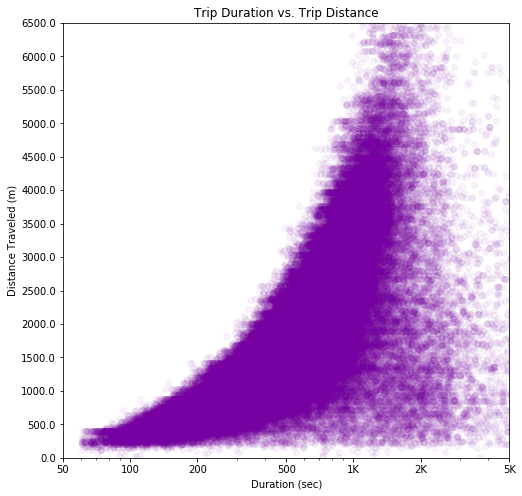

## Trip Duration & Distance by Day

When looking at the data distribution of trip distance and trip duration the shape of the data is fairly uniform for both when observed by each day of the week, with minor exceptions such as sharper edges for trip distance vs. Tuesday.

Observing trip duration and distance by user type, however, is when the difference in data becomes apparent. For trip duration vs. user type, the data maintains a similar shape but the data appears to shift towards lower values in user type order of customer -> subscriber -> bike share. For trip distance vs. user type the amount of data in the higher values decreases as the lower values increase, creating wider shapes beneath the median values, in user type order of customer -> subscriber -> bike share.

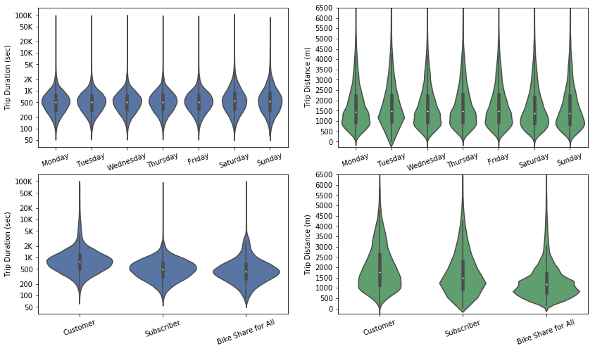

## User Type by Weekday

By plotting a count of trips made by day with user types, it reveals that subscribers account for an overwhelming majority of trips for all days. It can also be seen that the decrease in subscribers making trips during Saturday and Sunday is approximately the same as the decrease in trips previously seen counted by day.

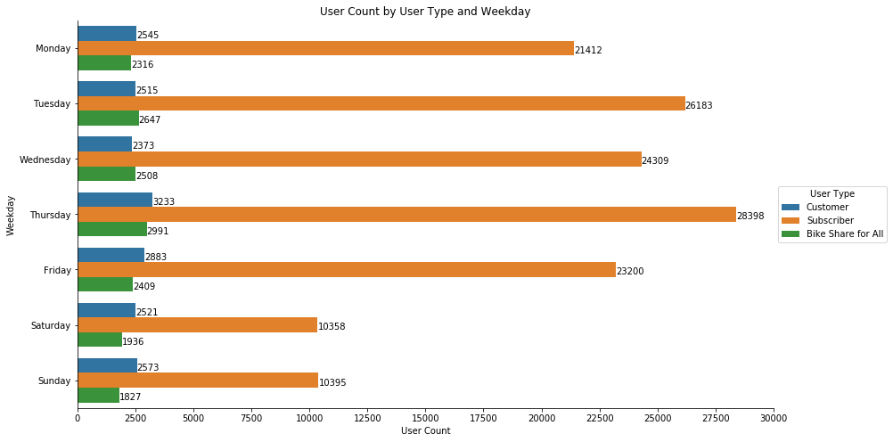

## Number of Trips by Hour per Day

Dividing the trips made by both weekday and hour gives a deeper look into patterns of use for the Ford GoBike system. By this comparison it shows a large majority of trips are made between Monday thru Friday and between two time frames of 7:00 to 10:00 and 16:00 - 19:00, and most trips for Saturday and Sunday are between 10:00 and 19:00 but not by any large margin.

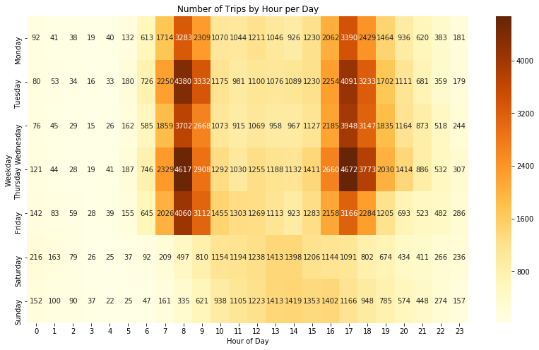

## Trip Duration & Distance by Day & User Type

When plotting the average trip time and distance by day per user type, the data shows that for both customers have significantly higher averages but with a larger confidence interval than subscribers, and Bike Share for All trips have generally the lowest averages with a similar confidence interval.

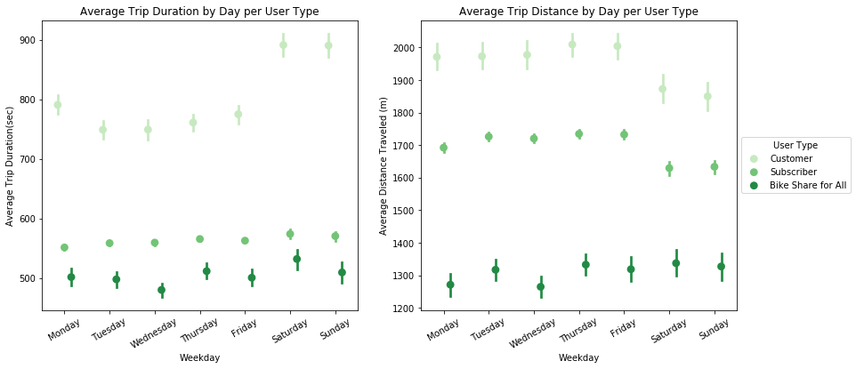

## Average Travel Rate by Day & User Type

However, when plotting the calculated travel rate of meters per second, the data is flipped and reveals that subscribers have a much higher travel rate than other groups with an extremely small confidence interval while customers have the lowest.

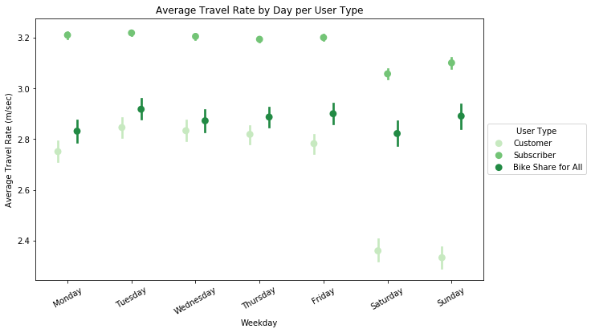

## Hourly Trips by Day & User Type

Limiting the data to when most trips were made, which would be the weekdays of Monday through Friday and the hours of 7:00 through 21:00, would provide a better idea of how these trends had formed.

By creating a grid to view the hourly trips made by day and user type, the data shows how the previous trend seen for trips made between 7:00 - 10:00 and 16:00 - 19:00 consists of almost exclusively subscribers. Additionally, subscribers count for more rides than customers for every hour of the sample.

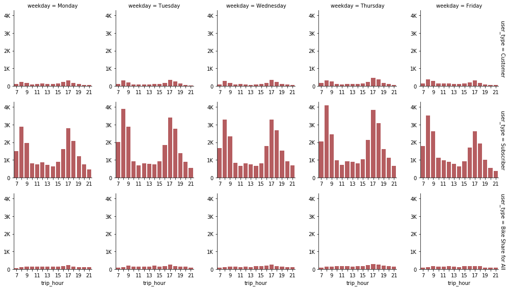